# NBA 2014-2017 Season Player Metrics Analysis by Esam Rhman

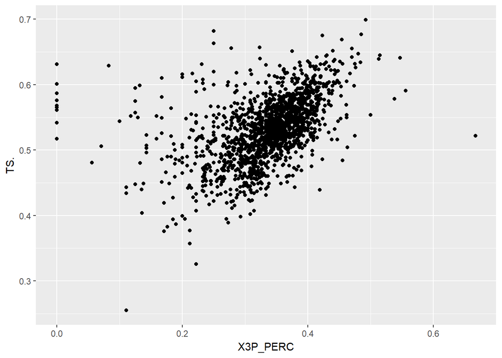

> Finally I also wanted to examine the relationship between the 3 supporting variables, it seems there’s a stronger correlation between 2 pointer shooting % and True shooting % compared to 3 pointer shooting %

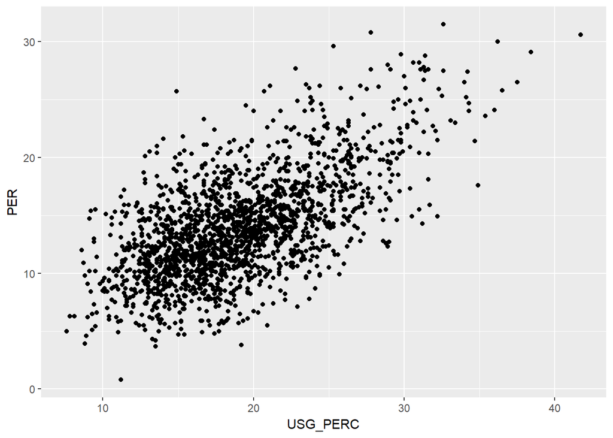

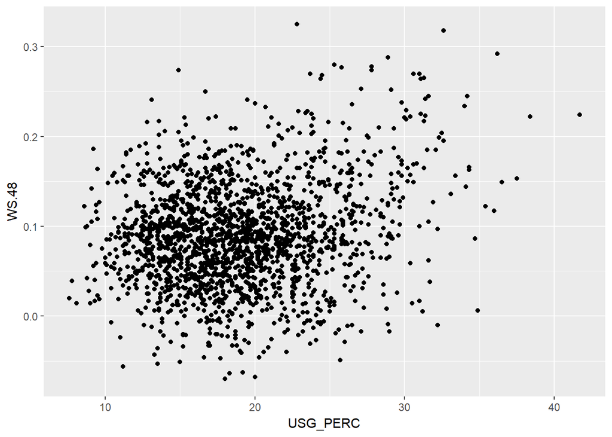

> As we observed with the correlation cofficient earlier, the scatter plot shows that there is roughly linear relationship between USG_PERC and PER, however this doesn’t translate over to WS.48. This is an interesting observation, this indicates just because a player is the focal point of the team doesn’t necessarily translate to team win contribution.

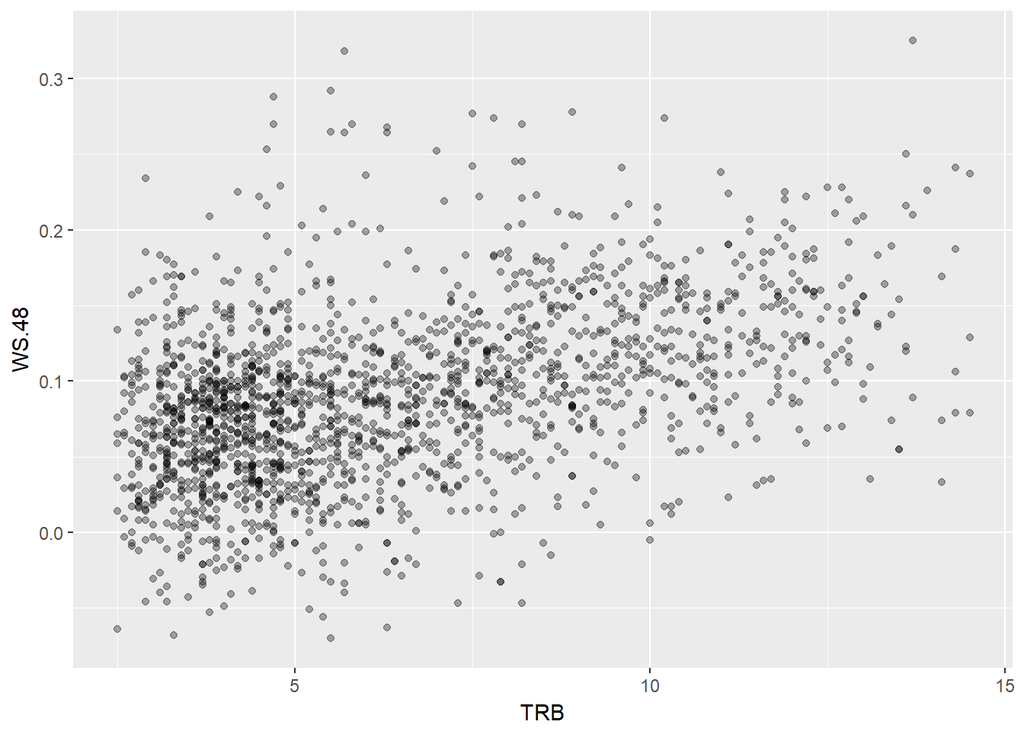

> The correlation here is clearly not as strong as some of the other variables we observed, rebounding doesn’t seem to have as strong of an impact on the win contribution as shooting percentage. Taking this one step further, lets check how the relationship looks like between WS.48 and TRB_PERC, which measures how well players rebound based on the available rebounding opportunities.

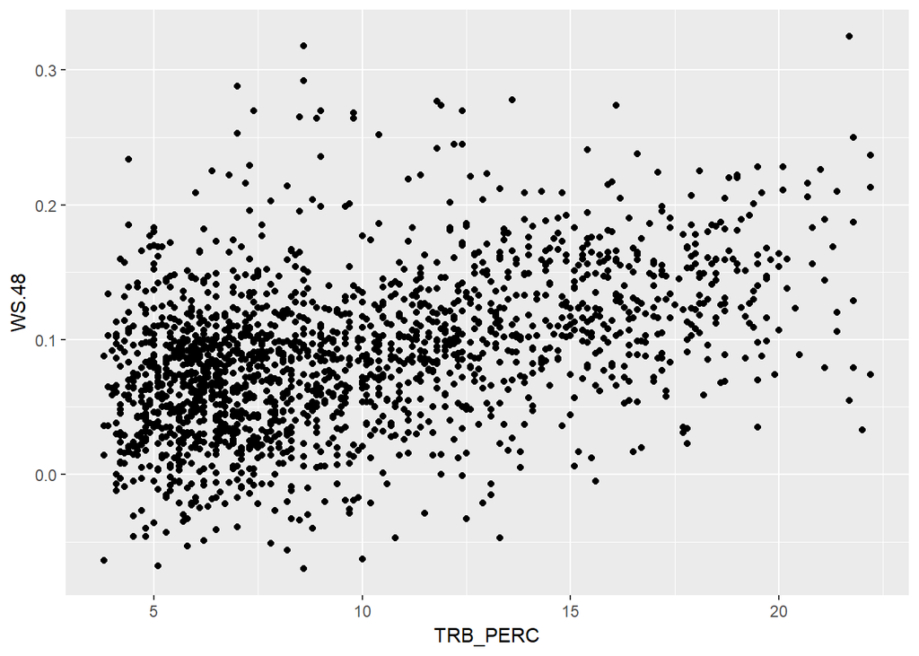

> Once again nothing conclusive, lets move on.

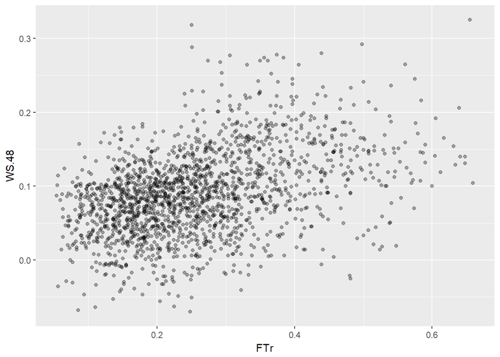

> Similar to rebounding, FTr seem to have some correlation to win contribution but again not as strong as some of the other variables. Most of the population seem to be condensed under 0.3 FTr where the correlation WS.48 seems all over the place.

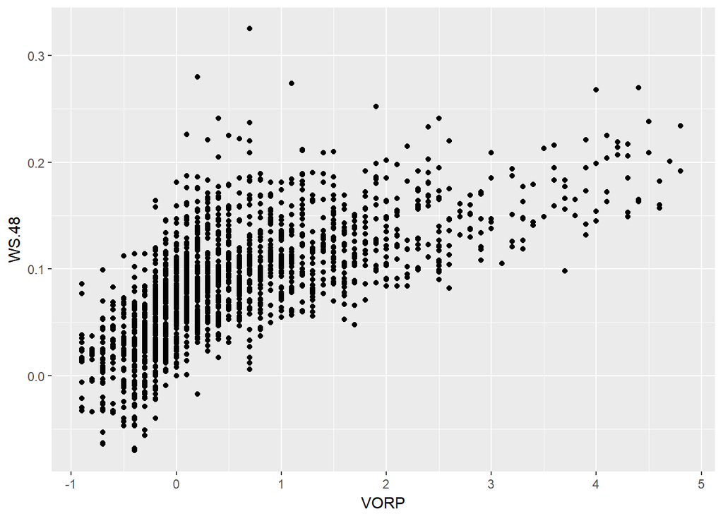

> Interesting relationship here, there seems to be a strong correlation between VORP but its not a simple linear relationship. There also seems to be a discrete natrue to VORP. Lets try changing the VORP scale.

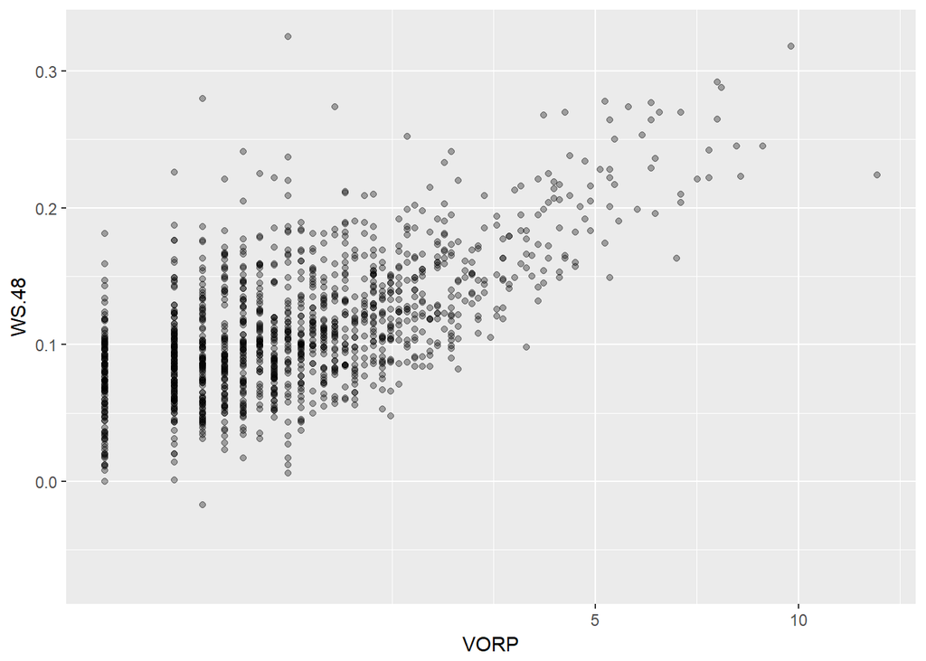

> By applying a ‘sqrt’ tranform to the x-axis the relationship seems to be more linear now, we can also clearly see the discrete nature of VORP for lower values. There are still quite a few extensions of these plots I’d like to explore to get the full picture, particularly adding a 3rd categorical variables such as Pos.

# Bivariate Analysis

### Talk about some of the relationships you observed in this part of the investigation. How did the feature(s) of interest vary with other features in the dataset?

There is a varying degree of correlation between the supporting variables and target variables. The goal is to understand which variables have an impact on the win contribution and overall player efficiency. The features of interest certainly exhibited higher correlation than the other variables in the dataset as observed with the ggpair plot. An interesting discovery was how the shooting % metrics correlated to Win Shares. It turns out True Shooting is the metric with the strongest correlation, however somewhat unexpectedly the X2P_PERC seems to be a larger component of that correlation vs X3P_PERC (TS is a weighted combination of both). The other feature of interest with a high correlation to WS.48 is VORP, this relationship however does not seem to be as linear as TS to WS.48. Finally there are some variables that had a moderate correlation to WS.48 as opposed to the non-existent correlation the remaining ‘other’ features exhibited. Examples of those are TRB and FTr

### Did you observe any interesting relationships between the other features (not the main feature(s) of interest)?

No

### What was the strongest relationship you found?

The 2 variables that exhibited a strong correlation to WS.48 and PER were TS. and VORP, both with a correlation coefficient over 0.7. VORP had the highest correlation of the two.

# Multivariate Plots Section

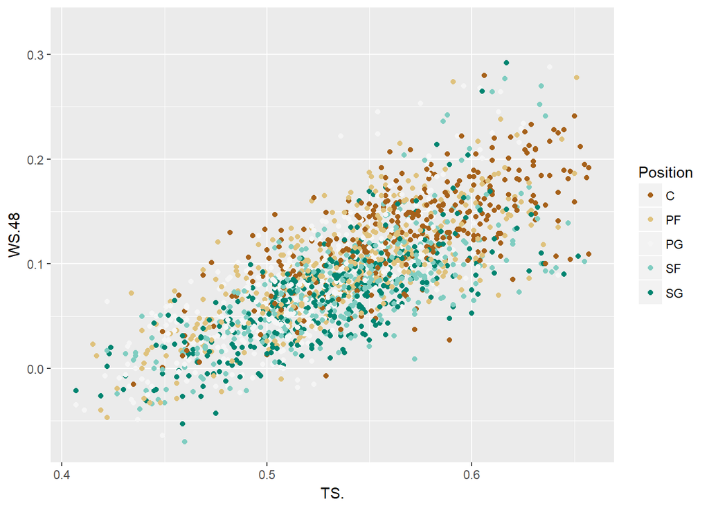

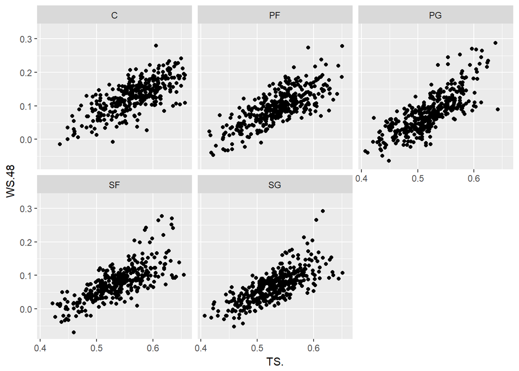

```
##   Pos       COR
## 1   C 0.7201446
## 2  PF 0.7745078
## 3  PG 0.7901972
## 4  SF 0.7375912
## 5  SG 0.7357632
```

> Further investigating the relationship between TS. and WS.48 by Pos reveals additional insight. When adding Pos as color to make the previous plot a multivariate plot, there doesn’t seem to be a very clear distinction across the positons. That said there does seem to be a bit of tendency for Centers and PFs to be on the higher side of the WS.48 given a constant TS. where Shooting Guards tend to be on the lower end. This suggests if Cs/PFs can achieve the same shooting efficiency as a SG they’d be a more valuable player overall. The other 2 plots attempt to investigate if there is distinction in strength or nature of the correlation between TS. and WS.48 across different positions. Indeed it seems that for PGs TS. has a greater impact on their WS.48 than the other positions, with Cs having the lowest correlation. A hypothesis could be that Centers rely slighly more on attributes other than shooting/scoring to contribute to their overall win contribution. Now lets look at a similar analysis but using PER as the target variable.

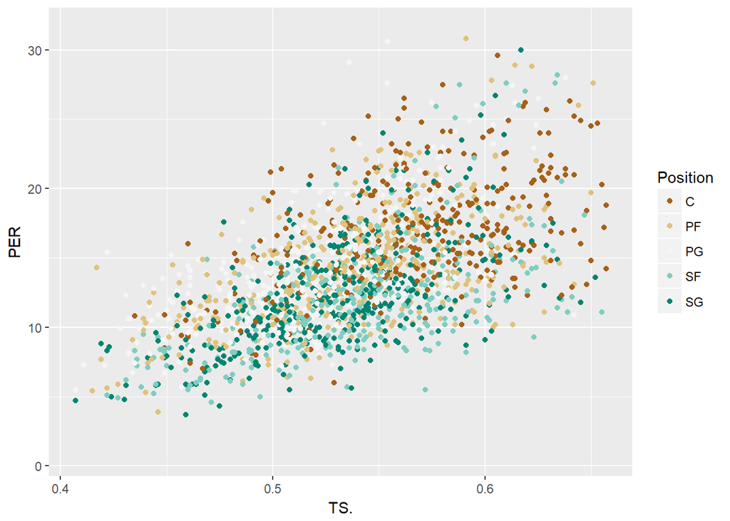

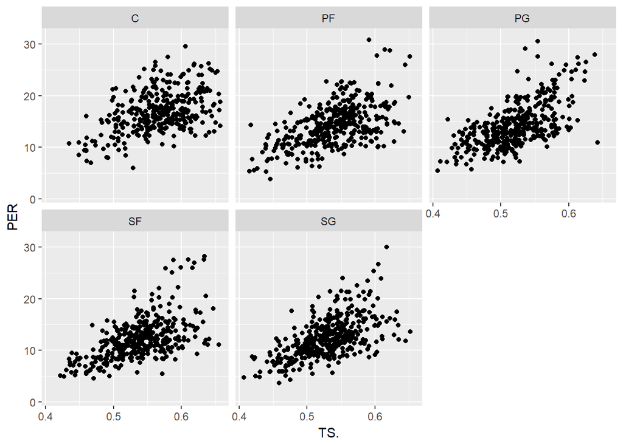

```
##   Pos       COR
## 1   C 0.4721368
## 2  PF 0.5866876
## 3  PG 0.6635174
## 4  SF 0.5788765
## 5  SG 0.5976883
```

> The relationship observed in the scatterplot does not reveal anything when colored by position. However when looking at the correlation strength by position there were some drastic variances. As observed in the previous analysis, PGs have a much higher correlation between TS. and PER, with Cs almost an entire 0.2 points lower in terms of the correlation coefficient. This further supports the theory that shooting % is a very important part of their game when it comes to overall production and efficiency, they might not have as many other sources of production to make up for a bad shooting % as Cs (rebounding/defense?) or other positions. Finally, I’m interested in observing these relationships colored by Season.

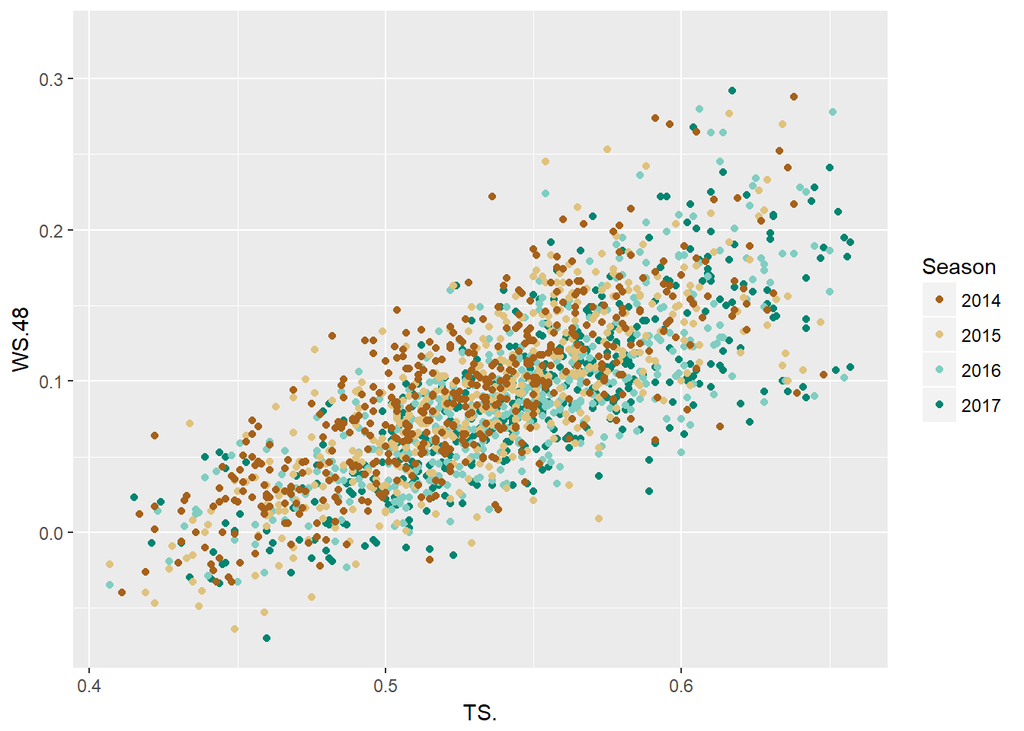

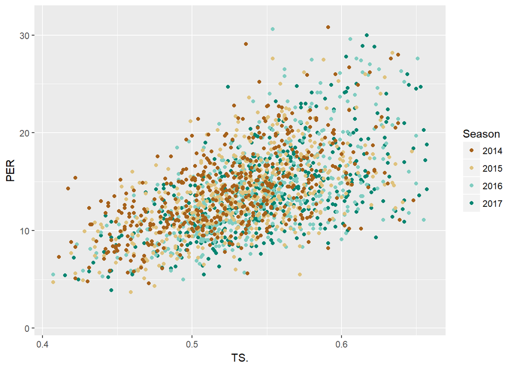

> Not much to note here, no distinction can be observed across the different Seasons which means the correlations observed previously have been consistent over time. Not lets move on to the next supporting variable and dig deeper into the USG_PERC relationships.

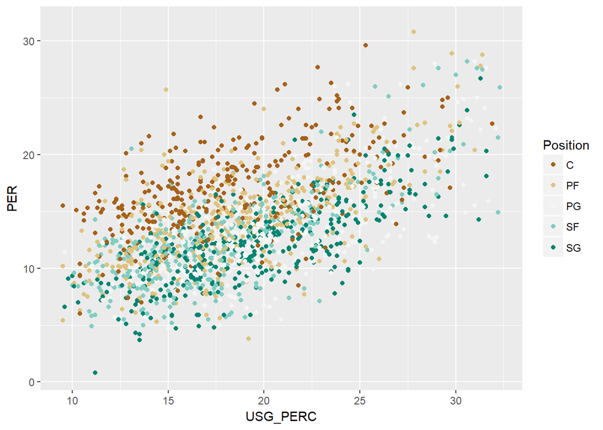

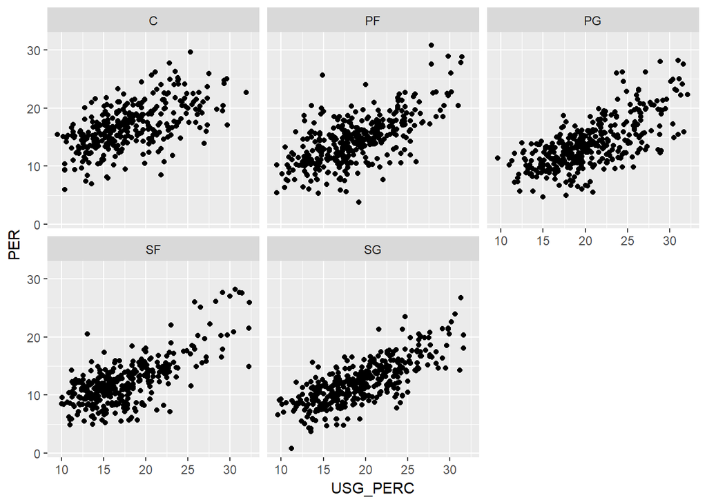

```
##   Pos       COR
## 1   C 0.6328093
## 2  PF 0.6600809
## 3  PG 0.7235126
## 4  SF 0.7194372
## 5  SG 0.7702680
```

> Interesting observations here. It seems that Cs and PFs to a lesser degree are on the higher spectrum of PER given a constant Usage Rate compared to the other positons. This indicates Cs and PFs are more valuable when utilized at the same rate as other position, an interesing observation considering Guards usually command more of the ball. When looking at the strength of correlation across the position we see variance once again. This time SGs seem to benefit the most from having a higher USG_PERC, while Cs and PFs are on the opposite side of the specturm. Once again this might indicate that Cs and PFs have other ways to be productive even if not utilized heavily as opposed to SGs. In the Bivariate analysis section we also observed that USG_PERC doesn’t correlate as strongly with WS.48 as PER. Lets investigate if this changes when adding Pos to the mix.

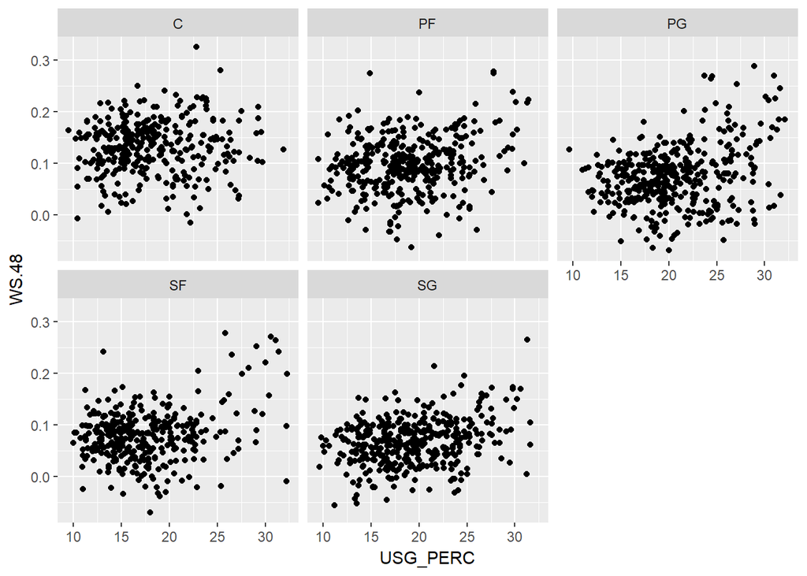

```
##   Pos        COR
## 1   C 0.08081089
## 2  PF 0.20434886
## 3  PG 0.37367239
## 4  SF 0.28142120
## 5  SG 0.32438488
```

> PGs seem to emerge with a moderate correlation but not enough to draw any conclusions, the scatterplots don’t seem to reveal much here either. Now lets look at a couple of the variables which exhibited moderate correlation to WS.48/PER, perhaps there is some hidden insight when analyzed by Pos

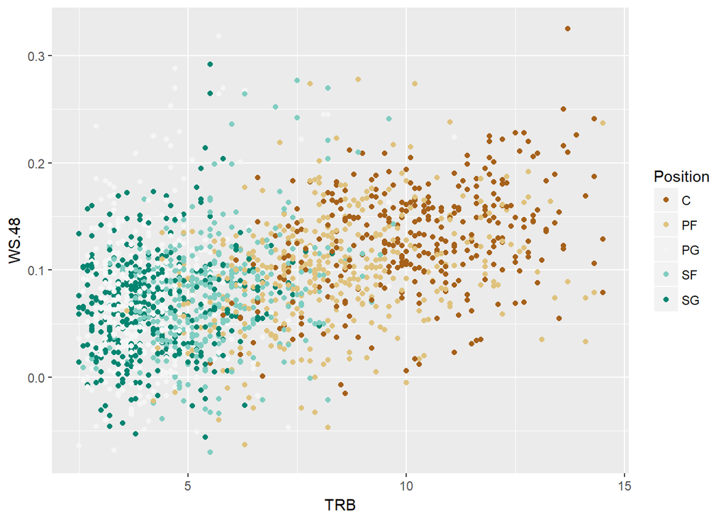

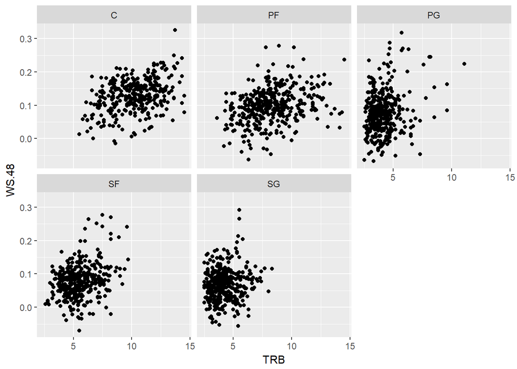

```
##   Pos       COR
## 1   C 0.4268600
## 2  PF 0.3091671
## 3  PG 0.2237797
## 4  SF 0.2950918
## 5  SG 0.1173092
```

> By coloring the TRB/WS.48 scatterplot by Pos we see it doesn’t tell us much because there is such a big variance of the value of TRB by position. Cs and Forwards clearly and unsurprisngly have more rebounds per 36 mins as compared to guards, but lets see if the correlation to WS.48 varies by position. Indeed looking at both the scatterplots and correlation coefficient by position, there is a huge variance across poitions. Centers seem to benefit the most from solid rebounding, with a correlation coefficient over 0.4, while guards don’t really exhibit any meaningful correlation. A hypothesis could be the types of rebounds Centers gather have a bigger impact on games as compared to rebounds made by guards. Lets examine this with PER as the target variable.

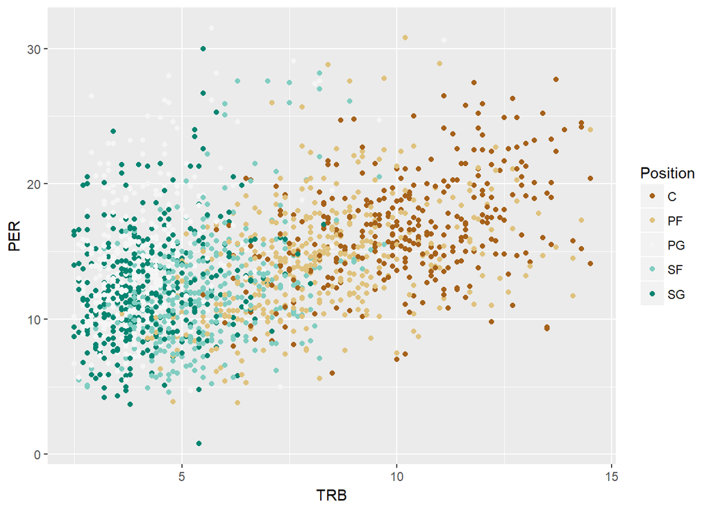

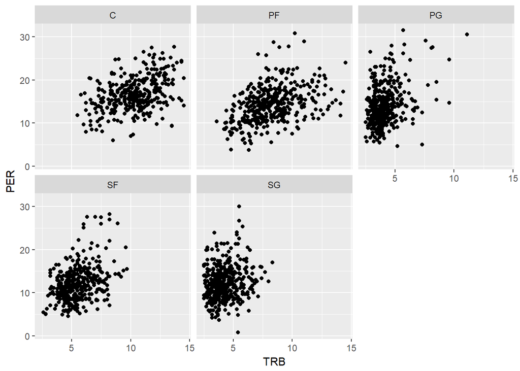

```
##   Pos       COR
## 1   C 0.4787148
## 2  PF 0.4151865
## 3  PG 0.3407070
## 4  SF 0.3716822
## 5  SG 0.1767651
```

> Similar variances can be seen here, except the correlation overall is stronger to PER as compared to WS.48. Once again this indicates that rebounding has a much bigger impact on a Center or Power Forward’s overall production compared to Guards. Lets take a look at another metric which had moderate correlation to the target variables, FTr.

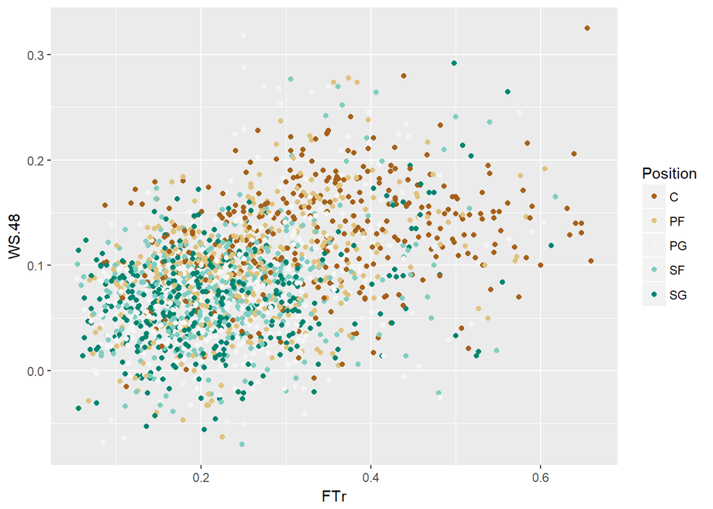

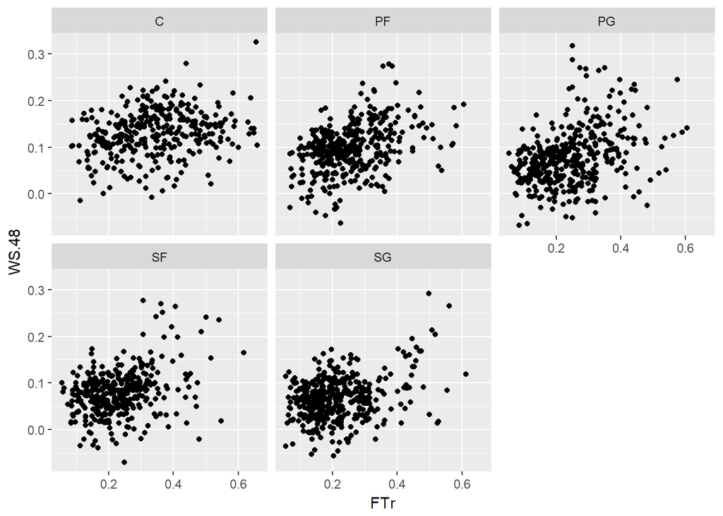

```
##   Pos       COR
## 1   C 0.2901976
## 2  PF 0.3613888
## 3  PG 0.3830949
## 4  SF 0.3221406
## 5  SG 0.3142087
```

> We don’t really reveal much when adding position as a 3rd variable here, perhaps the only takeaway is that PGs seem to benefit more from FTr than other positions when it comes to overall win contribution. Lets take one more look with correlation to PER.

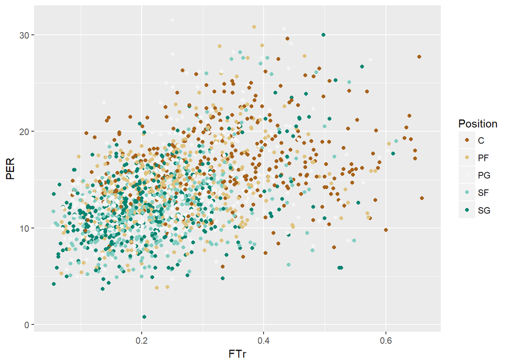

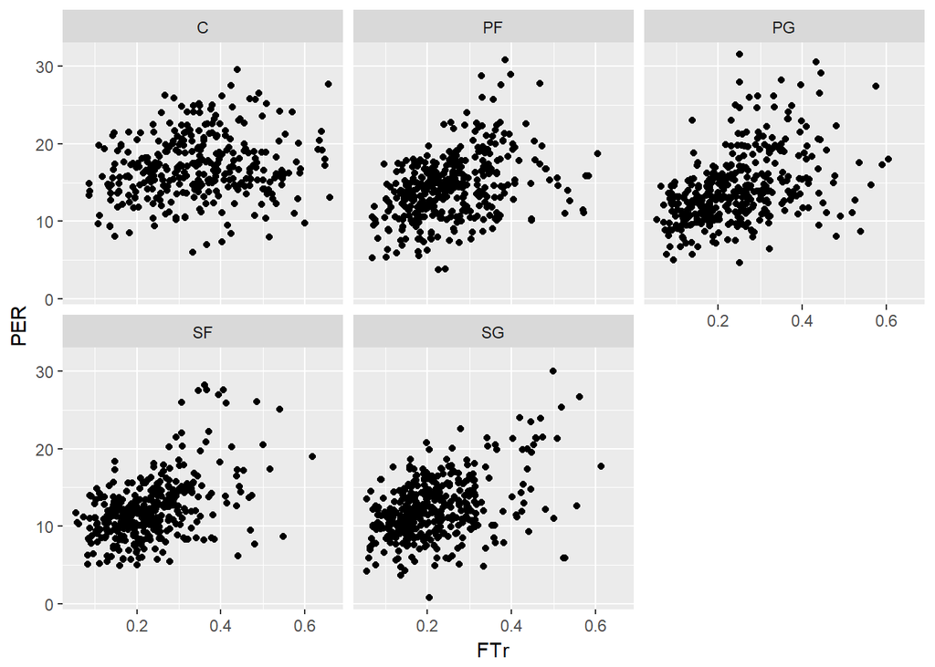

```
##   Pos       COR
## 1   C 0.1706420
## 2  PF 0.2935818
## 3  PG 0.4456761
## 4  SF 0.4558014
## 5  SG 0.4372954
```

> When it comes to PER, there seems to be more noticeable split between PGs, SFs, and SGs, compared to Cs and PFs. The former 3 position have a much higher correlation between their ability to get to the free throw line and their overall production. Its not a strong correlation but nonetheless an interesting observation. Finally we’ll dig into the supporting variable which we observed the storngest correlation to WS.48/PER, VORP.

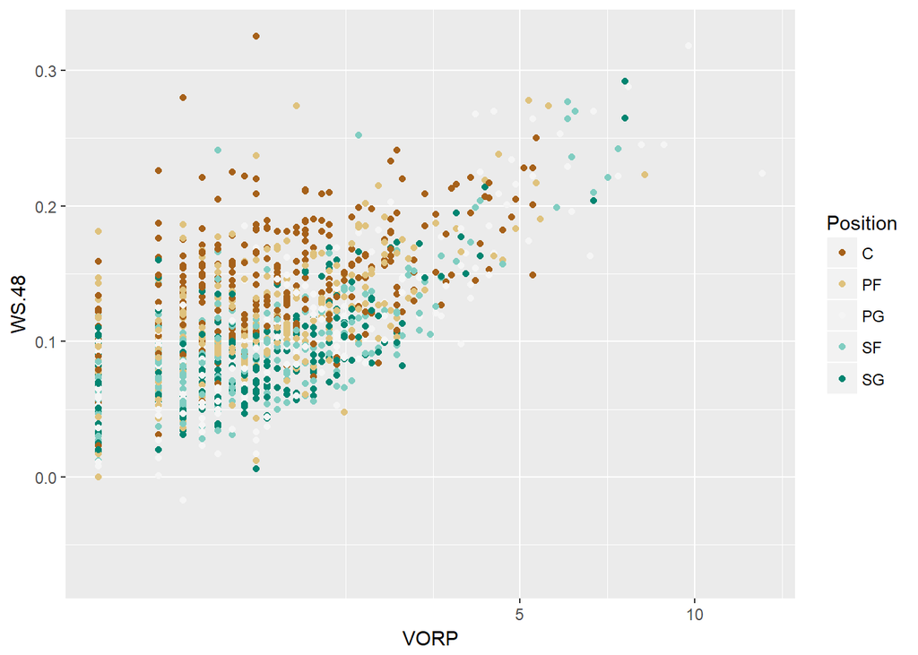

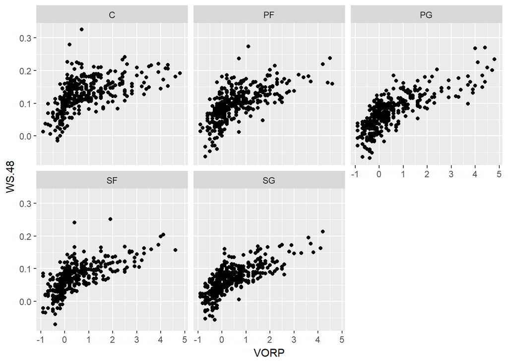

```
##   Pos       COR
## 1   C 0.5560500
## 2  PF 0.6820489
## 3  PG 0.8047235
## 4  SF 0.7661691
## 5  SG 0.7670240
```

> A few observations here.When adding the position variable in the scatterplot, we can observe that for a constant VORP Cs and PFs once again seem to have a higher WS.48. That said this seems to be the pattern for the lower values of VORP, once we get into the higher values that pattern is not as clear. This builds on the theory that due to their ability to contribute in other ways then point-scoring, Cs and PFs tend to have higher impact on overall wins than other positions Another observation is looking at the correlation between VORP and WS.48 by Pos. Cs seem to have significantly lower correlation compared to other positions, with PGs standing out with a 0.8 correlation coefficient. This also supports the aforementioned hypothesis. Now we’ll look at PER.

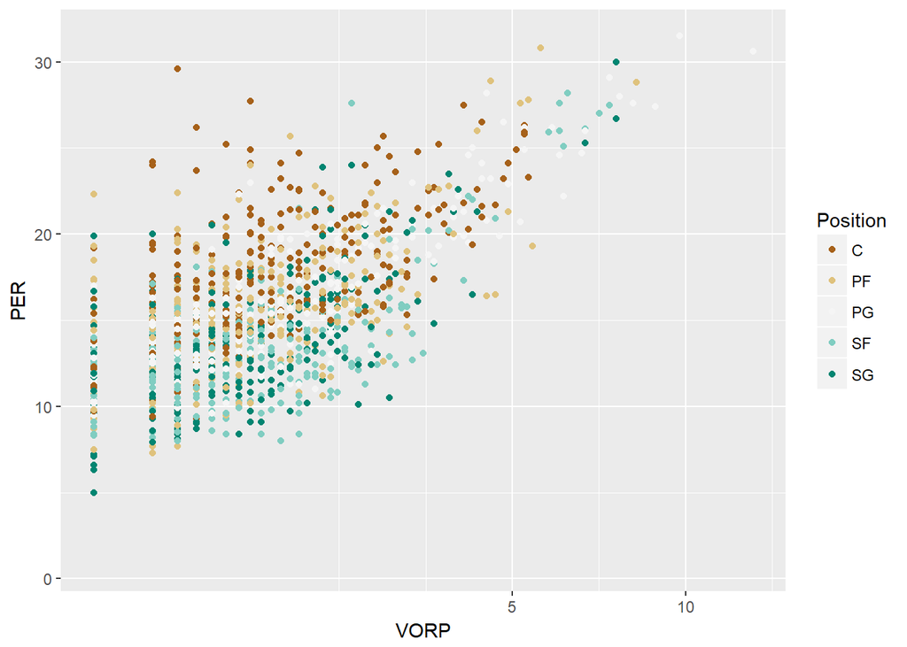

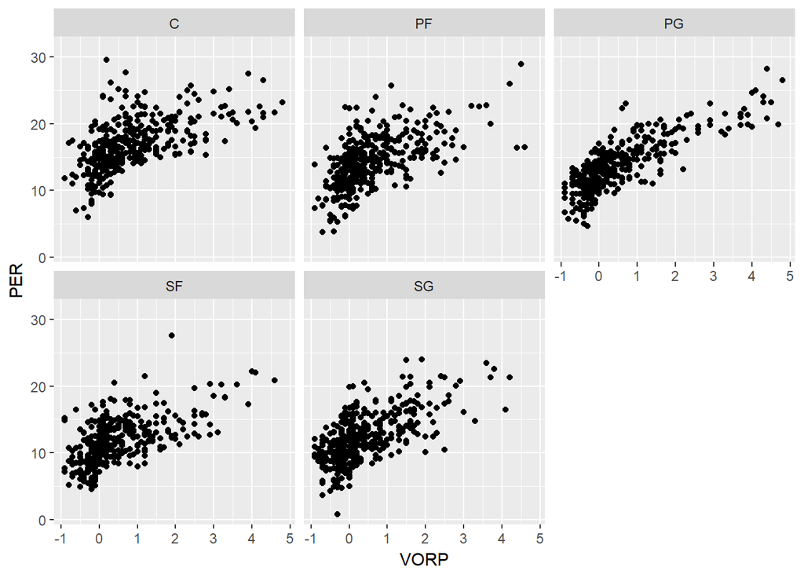

```
##   Pos       COR
## 1   C 0.6102424
## 2  PF 0.6591760
## 3  PG 0.8485489
## 4  SF 0.7438945
## 5  SG 0.6961332
```

> Very similar observations to the WS.48 plots.

# Multivariate Analysis

### Were there any interesting or surprising interactions between features?

Probably the biggest unexpected interaction was between USG_PERC, PER, and Pos. I did not expect there to be such a drastic variance between the correlation of usage to overall production output for a player based on position. It completely changes the way you evaluate the value of different positions.

# Final Plots and Summary

### Plot One

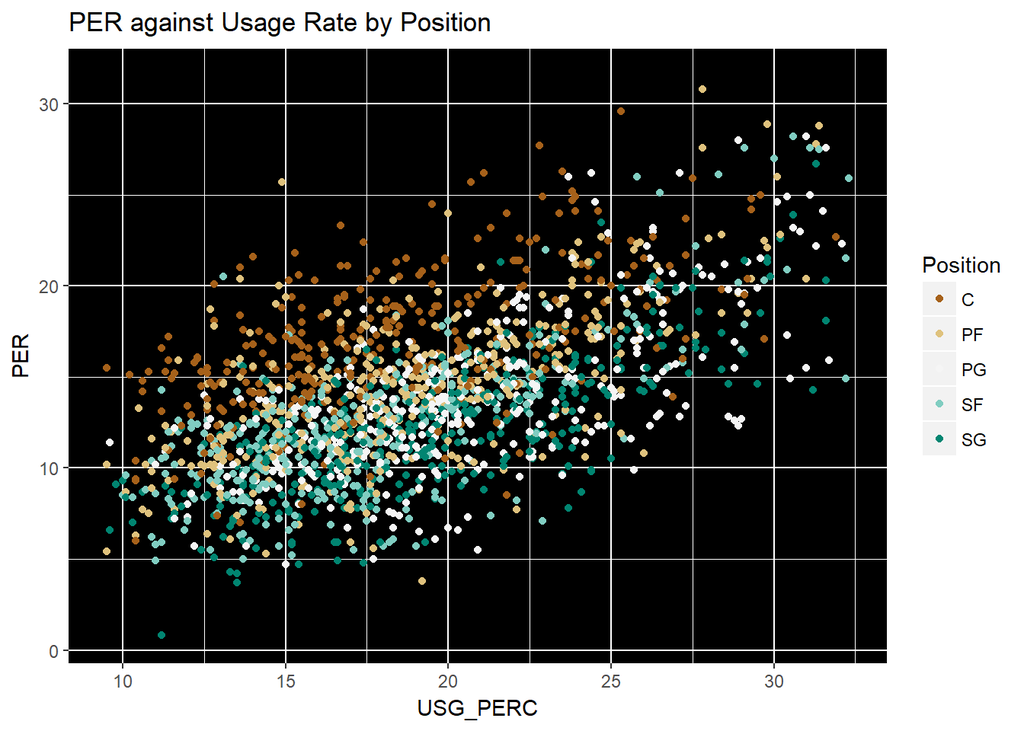

### Description One

The correlation between PER and USG_PERC is illustrated by this plot, but more interesting is how the PER of Centers and to a lesser degree, PFs is higher at a constant Usage Rate compared to other positions

### Plot Two

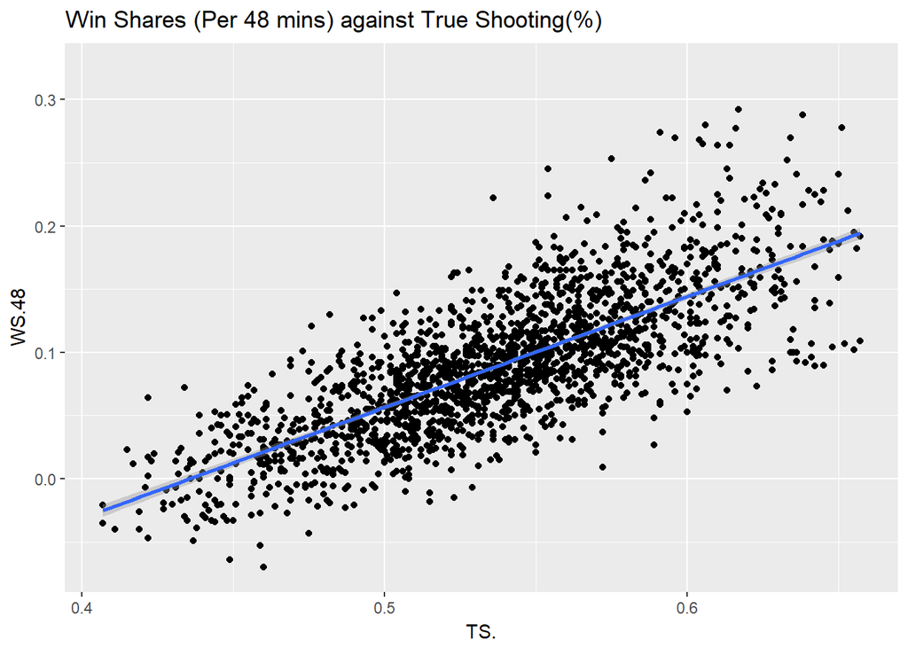

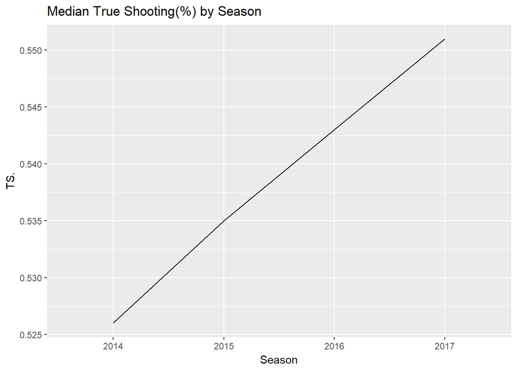

### Description Two

The first plot illustrates the strong linear correlation between True Shooting (%) and Win Shares per 48 mins (just under 0.8 correlation coefficient) with a straight line fit. The 2nd plot illustrates how the NBA has responded to this with the median TS. steadily increasing by Season.

### Plot Three

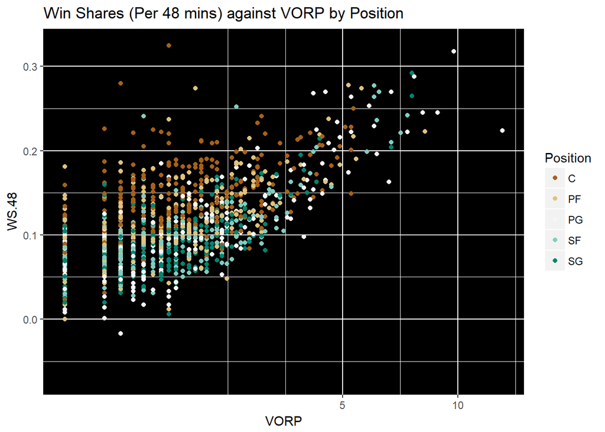

### Description Three

This plot illustrates the strongest correlation we’ve observed, which is between VORP and WS.48. A ‘sqrt’ transform was performed on the x-axis which resulted in a more linear representation of the relationship. Coloring the plot by Position brought to light the superiority of the C and PF positions given a constant VORP in terms of Win Shares, however, this superiority loses shape as VORP increases.

# Reflection

The nba dataset intitally contained over 2000 observation for player season stats since the 2014 season. I started by doing some data cleansing to handle entries of low statisticial significance, and group some low quantity Pos entries. Following this I began with doing analysis between various variables to try to find some useful correlations. Eventually I narrowed my focus on a few variables:

- Supporting variables: Pos, TS., USG_PERC, TRB, FTr, VORP
- Target variables: WS.48, PER

I was able to conclude that VORP and TS. had the highest correlation to WS.48 and PER, while USG_PERC has a high impact on PER. Upon investigating these relationships I was able to uncover some interesting takeaways:

There are a few limitation to this dataset. First of all this data is only representative of the past 4 seasons, perhaps older data might reveal some different trends. Also there are other advanced metrics not included here, especially on the defensive side of the ball, which would shed some more insight into some of the hypothses mentioned above.